# Forecasting Consumer price index

Bimal

5/21/2023

## Problem Statment

I want to predict the US Consumer Price Index (CPI) from Jan 2021 to July 2021.

The CPI is a measure of the prices of a basket of goods and services that are typically purchased by consumers.This basket covers various categories such as food, housing, transportation, healthcare, education, recreation, and more. The items in the basket and their relative weights are periodically updated to reflect changes in consumer spending patterns.

Predicting the Consumer Price Index is crucial for understanding and managing inflation, informing economic policies, facilitating wage adjustments, making investment decisions, and ensuring the stability and well-being of the economy and its participants.

For example, the CPI is a widely used measure of inflation, which is the rate at which prices for goods and services are increasing over time. Predicting the CPI allows economists, policymakers, and businesses to monitor and anticipate changes in the overall level of prices in the economy. It provides valuable insights into the inflationary pressures and helps in formulating appropriate monetary and fiscal policy. Accurate CPI predictions enable governments, central banks, and policymakers to make informed decisions regarding economic planning and policy adjustments. By understanding the future direction of prices, policymakers can take measures to manage inflation, stabilize the economy, and ensure sustainable economic growth. Currently, CPI is one of the key indicators that the federal reserve use to determine the interest rate.

However, predicting CPI can be extremely challenging due to several factors. The CPI is a complex index. The basket of goods and services is constantly changing, as new products are introduced and old products are discontinued. This makes it difficult to accurately predict the CPI, as the composition of the basket is constantly changing.The CPI is also affected by a number of factors, including economic growth, interest rates, and government policies. These factors can change rapidly, making it difficult to predict how they will affect the CPI.

Despite these challenges, we are going to attempt to predict CPI using time series analysis.

## Data Processing

The data was pulled from [kaggle.](https://www.kaggle.com/datasets/varpit94/us-inflation-data-updated-till-may-2021)

The data contains the monthly US CPI from 1913 to July 2021.

```r
cpi <- read.csv("D:/Desktop/UChicago/Classes/Spring Term 2023 Time Series Analysis and Forecasting/Project/USCPI.csv")

head(cpi)
```

```
##      Yearmon CPI
## 1 01-01-1913 9.8
## 2 01-02-1913 9.8
## 3 01-03-1913 9.8
## 4 01-04-1913 9.8
## 5 01-05-1913 9.7
## 6 01-06-1913 9.8
```

Convert Yearmon into date format and check for missing values.

```r
#Sys.setlocale("LC_TIME", "es_ES.UTF-8")

cpi$Yearmon<- as.Date(cpi$Yearmon, format = "%d-%m-%Y")


# Check for NAs after conversion
if (any(is.na(cpi$Yearmon))) {
  print("Warning: NAs found after date conversion.")
} else {
  print("No Missing Values")
}
```

```
## [1] "No Missing Values"
```

**Splitting the data into train and test where test set is 7 months of 2021.**

```r
# Split the data into train and test sets
train <- cpi[cpi$Yearmon < "2021-01-01", ]
test <- cpi[cpi$Yearmon >= "2021-01-01", ]

#converting df to ts with frequency of 12
traints <- ts(cpi$CPI, start = 1913)
testts <- ts(cpi$CPI,  start = 2021)

#traints <- ts(train$USD, frequency = 12, start = 1979)
#testts <- ts(train$USD, frequency = 12, start = 2021)
```

# EDA + Data properties

**Plots of the timeseries**

Looking at rolling mean and SD of the data, you can clearly see that there is an upward trend especially starting from 1970.

```r
#install.packages("xts")
library(xts)
```

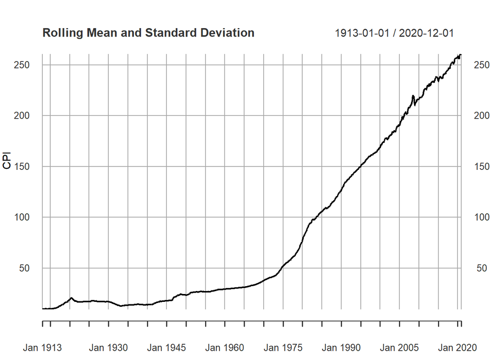

```r
trainxts <- xts(train$CPI, order.by = train$Yearmon)
rollmean <- rollmean(trainxts, k = 30)
rollsd <- rollapply(trainxts, width = 30, FUN = sd, fill = NA)

# Create a plot
plot(trainxts, main = "Rolling Mean and Standard Deviation", xlab = "Date", ylab = "CPI")
```

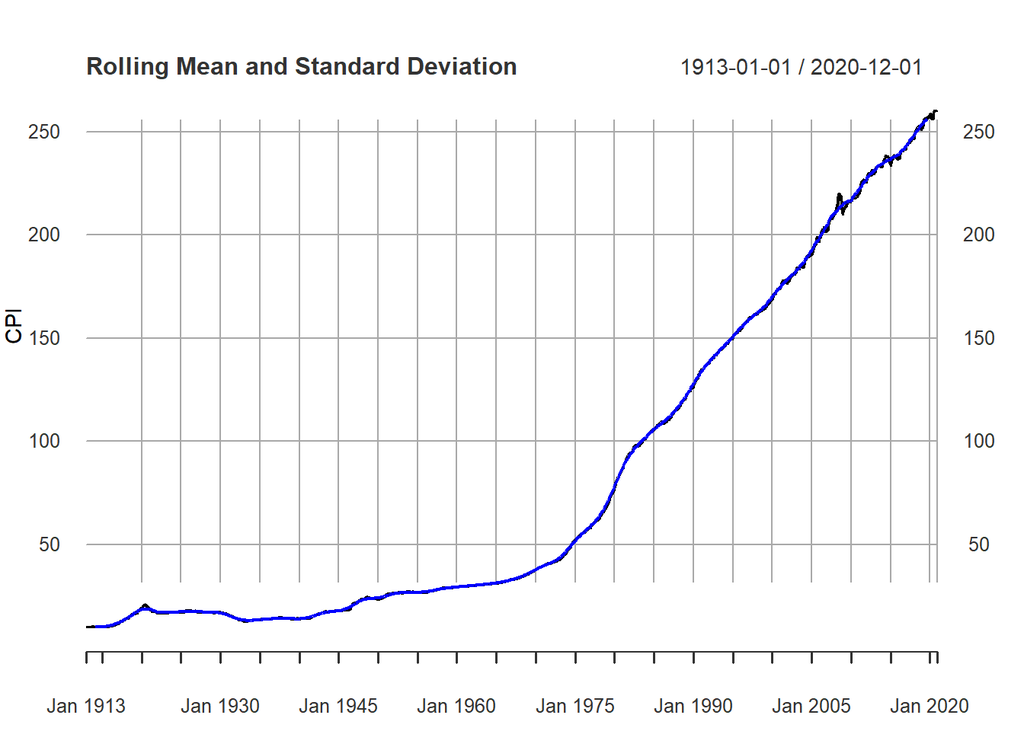

```r
lines(rollmean, col = "blue", lwd = 2)
```

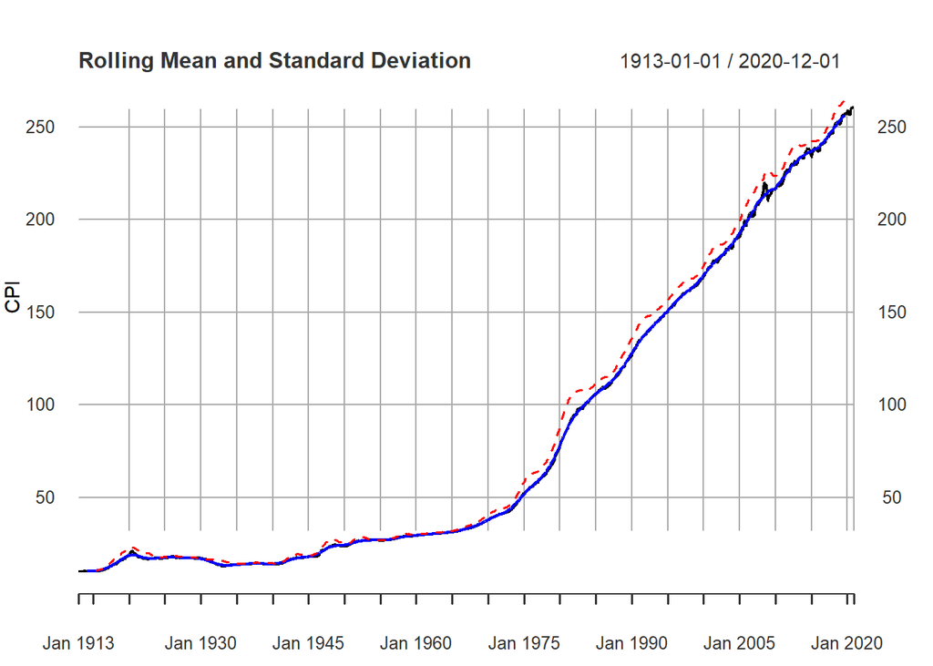

```r
lines(rollmean + 2 * rollsd, col = "red", lty = 2, lwd = 1.5)
```

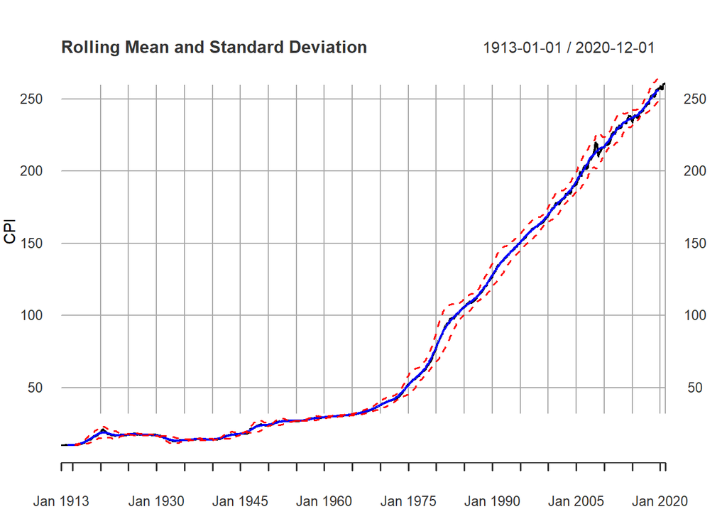

```r
lines(rollmean - 2 * rollsd, col = "red", lty = 2, lwd = 1.5)
```

**Checking for seasonality**

Checking for seasonality, there doesn’t seem to be a seasonal component.

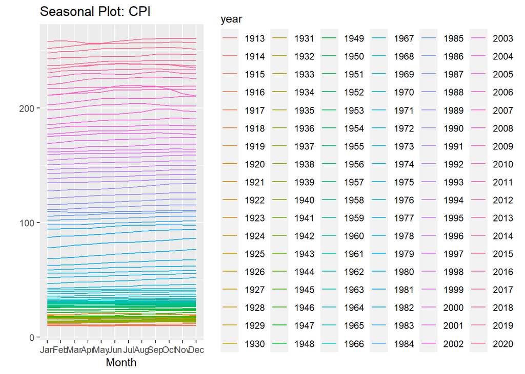

```r
library(ggplot2)

#converting df to ts with frequency of 12
traints1 <- ts(train$CPI, frequency = 12, start = 1913)

library(forecast)
ggseasonplot(traints1, main = "Seasonal Plot: CPI")
```

**Checking for stationary**

Stationarity is a statistical property of a time series that means that the mean, variance, and autocorrelation of the series do not change over time. If a time series is not stationary, it may be difficult to forecast future values accurately.

We already saw from the EDA above that the time series is not stationary due the trend component. Let’s check for autocorrelation as well.

**Autocorrelation Check using ACF and PACF plots**

ACF plot shows that the timeseries is autocorrelated;hence, non-stationary. If the ACF plot shows a significant correlation coefficient at multiple lags, it suggests that the time series has a strong autocorrelation and may be non-stationary.An autocorrelation function (ACF) plot is a graph that displays the correlation between a time series and its lagged values.

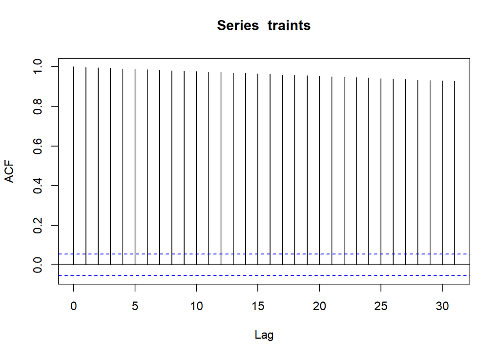

```r
acf_data <- acf(traints)
```

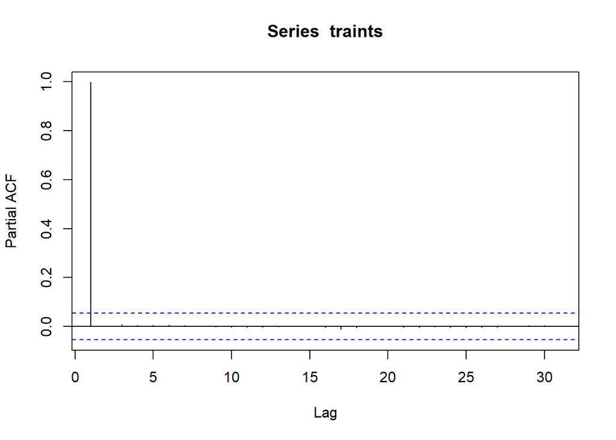

```r
pacf_data <- pacf(traints)
```

**Quantitative stationary check using ADF and KPSS Tests**

The ADF test tests for the presence of a unit root in the time series. A unit root is a value that causes the time series to trend upwards or downwards over time. he ADF test is based on the following null and alternative hypotheses:

Null hypothesis: The time series is non-stationary.

Alternative hypothesis: The time series is stationary.

The KPSS test is a trend stationarity test, which means that it tests for the presence of a trend in the time series. The KPSS test is based on the following null and alternative hypotheses:

Null hypothesis: The time series is stationary.

Alternative hypothesis: The time series is not stationary.

For ADF, the p-value is 0.99, we fail to reject the null hypothesis of non-stationary for Adf, which means that there is insufficient evidence to support the alternative hypothesis of stationarity.

For KPSS, we can reject the null hypothesis of stationarity, which means we have found evidence that supports the alternative hypothesis of non-stationarity.

Therefore, we need to make the data stationary before fitting any model.

```r
library(tseries)
# Perform the ADF test
  adf_result <- adf.test(traints)
    cat(paste0(colnames(data), " ADF test p-value: ", adf_result$p.value, "\n"))
```

```
##  ADF test p-value: 0.99
```

```r
# Perform the KPSS test
  kpss_result <- kpss.test(traints)
  cat(paste0(colnames(data), " KPSS test p-value: ", kpss_result$p.value, "\n"))
```

```
##  KPSS test p-value: 0.01
```

**Differentiate to make time series stationary**

For ADF, the p-value is 0.01, we reject the null hypothesis of non-stationary for Adf, which means that there is enough evidence to support the alternative hypothesis of stationarity.

For KPSS, we can reject the null hypothesis of stationarity, which means we have found evidence that supports the alternative hypothesis of non-stationarity.

This implies a trend stationary time series.Trend stationary means that the time series exhibits a stable and consistent trend over time, while the mean and variance of the series remain constant or vary around a stable level.

We also see seasonality, which makes sense as prices of goods and services can exhibit significant seasonality. The strong trend component in the non-differenced original data may be masking the seasonality in the original data.The seasonality may be more pronounced in the differenced data because the trend component has been removed.

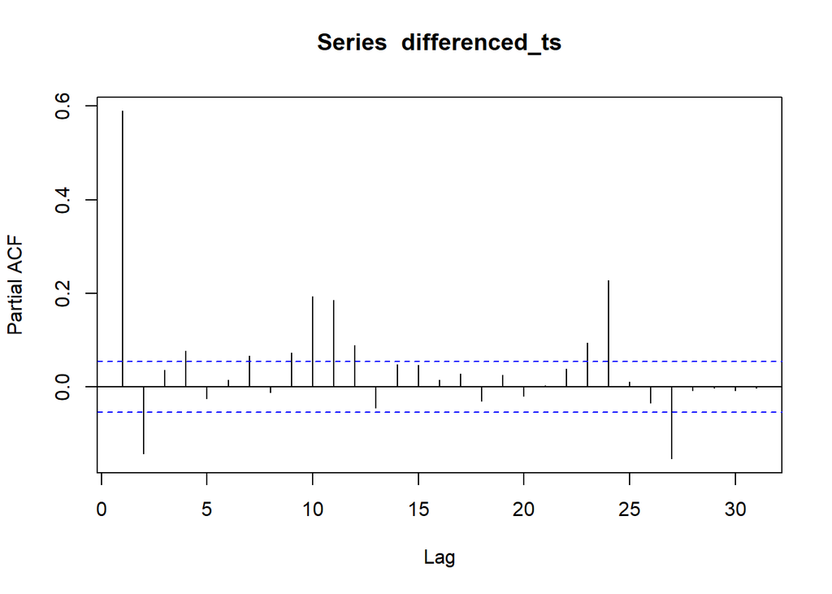

```r
library(tseries)
differenced_ts <- diff(traints,lag=1)

#acf(differenced_ts)

pacf(differenced_ts)
```

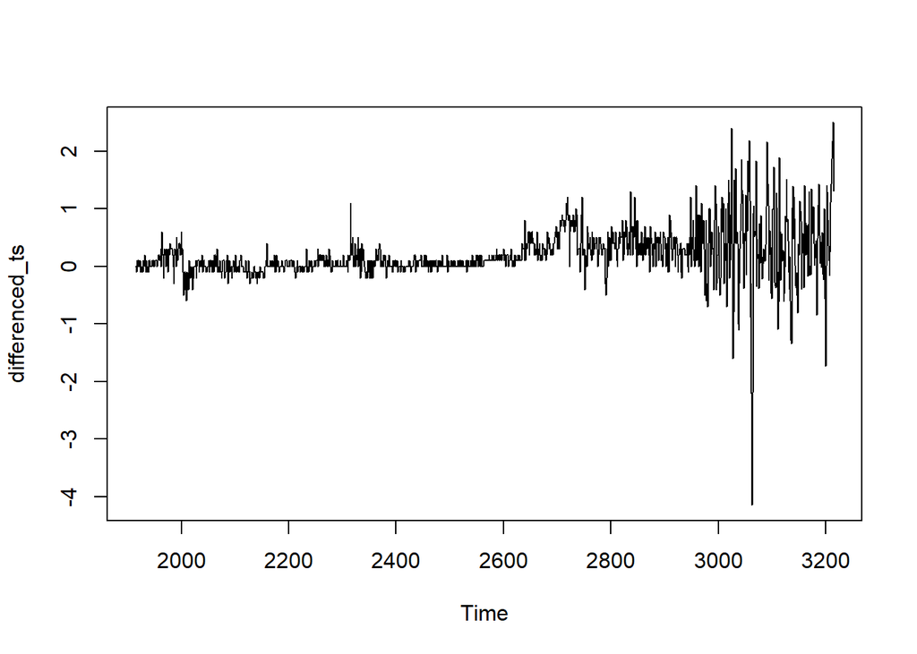

```r
plot(differenced_ts)
```

```r
# Perform the ADF test
  adf_result <- adf.test(differenced_ts)
    cat(paste0(colnames(data), " ADF test p-value: ", adf_result$p.value, "\n"))
```

```
##  ADF test p-value: 0.01
```

```r
# Perform the KPSS test
  kpss_result<- kpss.test(differenced_ts)
  cat(paste0(colnames(data), " KPSS test p-value: ", kpss_result$p.value, "\n"))
```

```
##  KPSS test p-value: 0.01
```

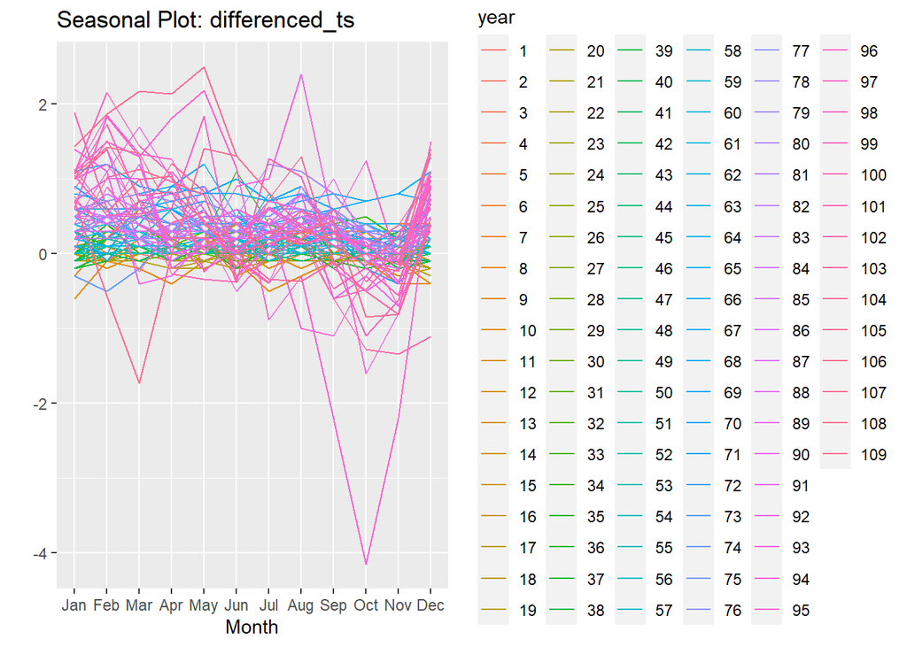

```r
#converting df to ts with frequency of 12
differenced_ts <- ts(differenced_ts, frequency = 12)

library(forecast)

ggseasonplot(differenced_ts, main = "Seasonal Plot: differenced_ts")
```

**Time Series Multiplicative Decomposition**

During the decomposition process, the time series is separated into different components, such as trend, seasonal, and remainder. The trend component captures the long-term patterns and direction of the time series, the seasonal component represents the repetitive patterns occurring over shorter periods (e.g., daily, weekly, or yearly), and the remainder (or residual) component represents the unexplained variation or noise remaining after accounting for the trend and seasonal components.

The remainder or residual component consists of the unpredictable and random fluctuations in the time series that cannot be explained by the identified trend and seasonal patterns. It represents the part of the data that is not captured by the underlying structure of the model.

Having a value close to 1 for the remainder is ideal for multiplicative decomposition. Since multiplying any value by 1 does not change its value, it means that the trend and seasonality components are able to explain most of the variation(not all) in the data.It means that the random component is relatively small, which makes it less likely to affect the forecast accuracy. Models such as Holt-Winters and SARIMA are are suitable for capturing the trend and seasonality of the time series.

The multiplicative decomposition model can be expressed as:

y(t) = T(t) * S(t) * R(t)

where:

y(t) is the original time series data T(t) is the trend component S(t) is the seasonality component R(t) is the residual component

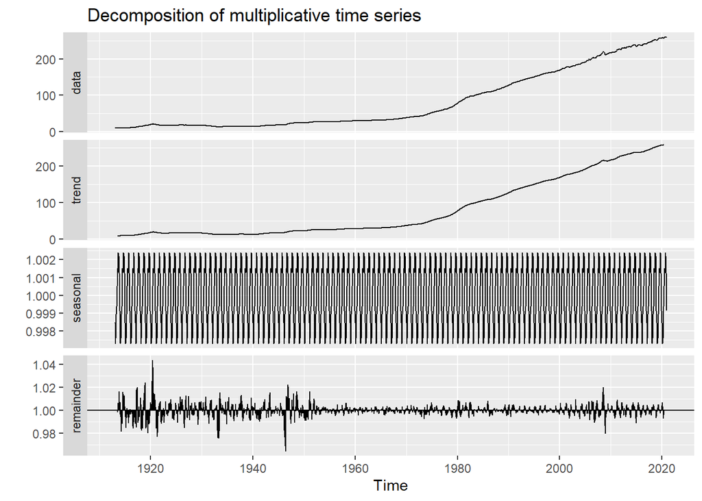

```r
decomposed_CPI <- decompose(traints1, type = "multiplicative")
autoplot(decomposed_CPI)
```

## SARIMA Models

Since the data is trend stationary and has a seasonal and trend component, we will first use SARIMA.

auto.arima() automatically selects the best order for the ARIMA model based on a statistical criterion such as the Akaike information criterion (AIC) or the Bayesian information criterion (BIC).auto.arima() is particularly useful for time series with complex patterns or seasonality, as it can identify appropriate seasonal orders and determine whether to use seasonal differencing. It also automatiaclly applies differencing to the time series to make it stationary. You can find out more about how auto.arima() works here: https://otexts.com/fpp2/arima-r.html

```r
#library(forecast)

baseline_model <- auto.arima(differenced_ts)


baseline_model
```

```
## Series: differenced_ts
## ARIMA(2,1,1)(0,0,2)[12]
##
## Coefficients:
##          ar1      ar2      ma1    sma1    sma2
##       0.5868  -0.1799  -0.9855  0.1351  0.1237
## s.e.  0.0278   0.0279   0.0053  0.0295  0.0255
##
## sigma^2 = 0.1125:  log likelihood = -423.83
## AIC=859.66   AICc=859.73   BIC=890.69
```

```r
#find the best ARIMA model using AICc
model_aicc <- auto.arima(differenced_ts, ic = "aicc", seasonal = TRUE)

summary(model_aicc)
```

```
## Series: differenced_ts
## ARIMA(2,1,1)(0,0,2)[12]
##
## Coefficients:
##          ar1      ar2      ma1    sma1    sma2
##       0.5868  -0.1799  -0.9855  0.1351  0.1237
## s.e.  0.0278   0.0279   0.0053  0.0295  0.0255
##
## sigma^2 = 0.1125:  log likelihood = -423.83
## AIC=859.66   AICc=859.73   BIC=890.69
##
## Training set error measures:
##                      ME      RMSE       MAE MPE MAPE      MASE         ACF1
## Training set 0.01184062 0.3346334 0.1998848 NaN  Inf 0.7641581 -0.002963997
```

```r
# find the best ARIMA model using BIC
model_bic <- auto.arima(differenced_ts, ic = "bic", seasonal = TRUE)

summary(model_bic)
```

```
## Series: differenced_ts
## ARIMA(0,1,3)(0,0,2)[12]
##
## Coefficients:
##           ma1      ma2      ma3    sma1    sma2
##       -0.3902  -0.3899  -0.1969  0.1349  0.1243
## s.e.   0.0280   0.0267   0.0287  0.0296  0.0258
##
## sigma^2 = 0.1122:  log likelihood = -422.15
## AIC=856.3   AICc=856.37   BIC=887.33
##
## Training set error measures:
##                      ME      RMSE       MAE MPE MAPE      MASE         ACF1
## Training set 0.01211938 0.3342011 0.1996981 NaN  Inf 0.7634442 -0.008711219
```

**AICc Model**

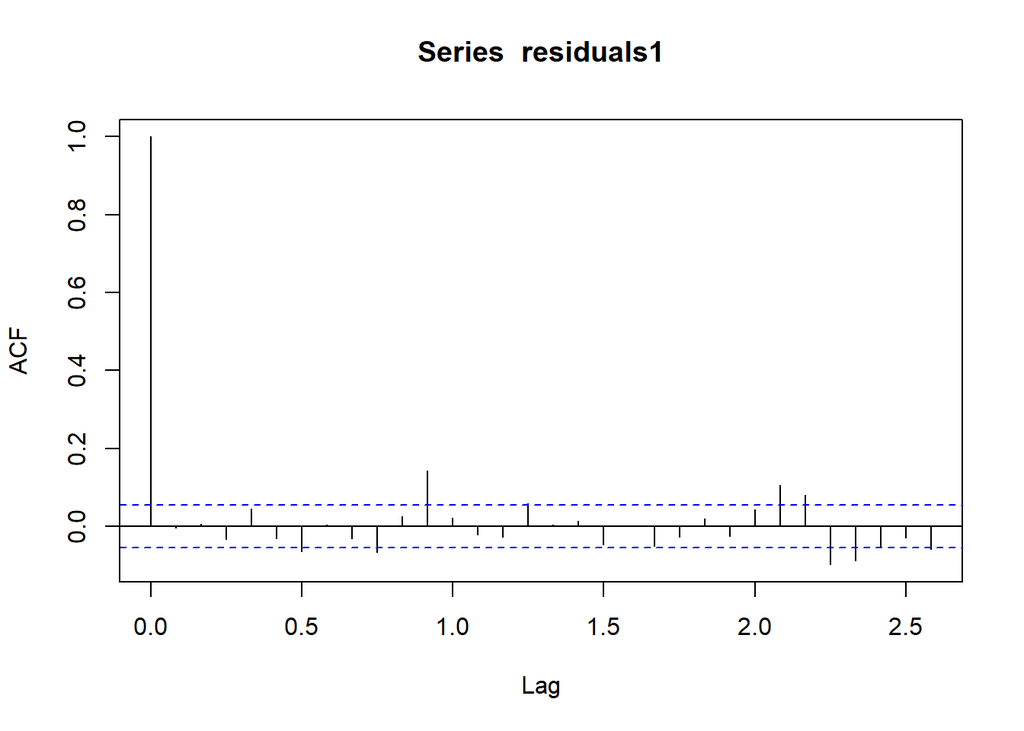

```r
residuals1 <- resid(baseline_model)
acf_resid1 <- acf(residuals1)
```

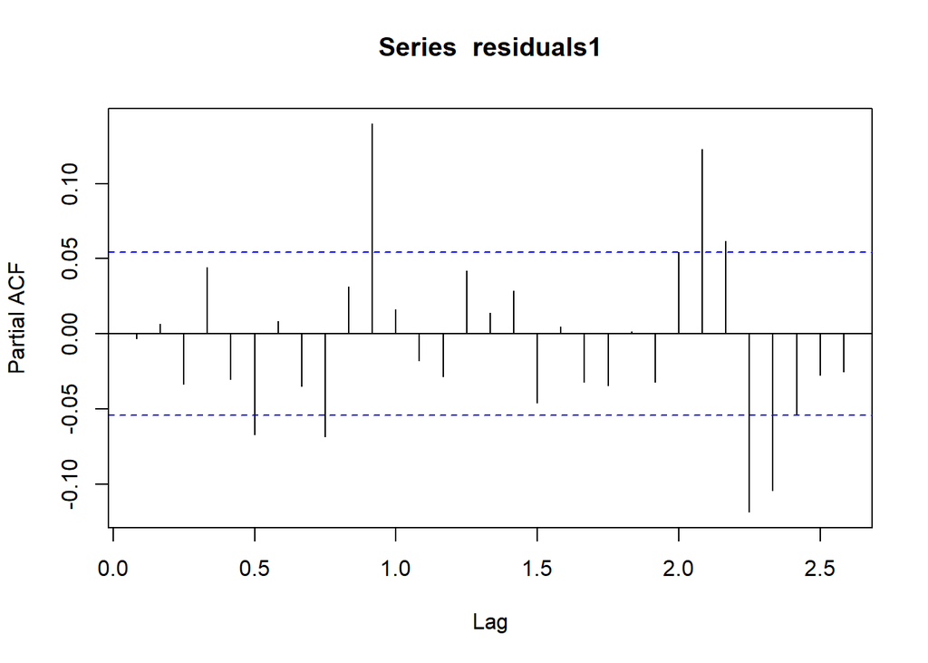

```r
pacf_resid1 <- pacf(residuals1)
```

```r
Box.test(baseline_model$residuals, type='Ljung-Box')
```

```
##
##  Box-Ljung test
##
## data:  baseline_model$residuals
## X-squared = 0.011465, df = 1, p-value = 0.9147
```

```r
# Perform the ADF test
  adf_result1 <- adf.test(baseline_model$residuals)
    #cat(paste0(colnames(data), " ADF test p-value: ", adf_result1$p.value, "\n"))
adf_result1$p.value
```

```
## [1] 0.01
```

```r
adf_result1
```

```
##
##  Augmented Dickey-Fuller Test
##
## data:  baseline_model$residuals
## Dickey-Fuller = -9.5734, Lag order = 10, p-value = 0.01
## alternative hypothesis: stationary
```

```r
# Perform the KPSS test
  kpss_result1 <- kpss.test(baseline_model$residuals)
kpss_result1
```

```
##
##  KPSS Test for Level Stationarity
##
## data:  baseline_model$residuals
## KPSS Level = 0.11892, Truncation lag parameter = 7, p-value = 0.1
```

**Checking for Normality and Heteroscedasticity for AICc Model**

The Shapiro-Wilk test is used to determine if a dataset significantly deviates from a normal distribution. In this case, with a p-value of less than 2.2e-16, which is extremely small, we reject the null hypothesis of normality. This indicates that the dataset being tested does not follow a normal distribution.We can also see from the qqplot, that residuals are not normal. This violates one of the assumption of the SARIMA models.

From the residual vs fitted values plot, McLeod.Li.test and the time series plot, we can see that there is Heteroscedasticity, which also violates another assumption of the model.Heteroscedasticity refers to a situation in which the variability or dispersion of errors (residuals) in a regression or time series model is not constant across different levels of the independent variables or across different time periods.

In conclusion, we should utilize and alternative model to ARIMA.

```r
#install.packages(fitar)
residual.analysis <- function(model, std = TRUE){
  library(TSA)
  #library(FitAR)
  if (std == TRUE){
    res.model = rstandard(model)
  }else{
    res.model = residuals(model)
  }
  par(mfrow=c(3,2))
  plot(res.model,type='o',ylab='Standardized residuals', main="Time series plot of standardized residuals")
  abline(h=0)
  hist(res.model,main="Histogram of standardized residuals")
  qqnorm(res.model,main="QQ plot of standardized residuals")
  qqline(res.model, col = 2)
  acf(res.model,main="ACF of standardized residuals")
  print(shapiro.test(res.model))
  k=0
}

residual.analysis(model=baseline_model)
```

```
##
##  Shapiro-Wilk normality test
##
## data:  res.model
## W = 0.8349, p-value < 2.2e-16
```

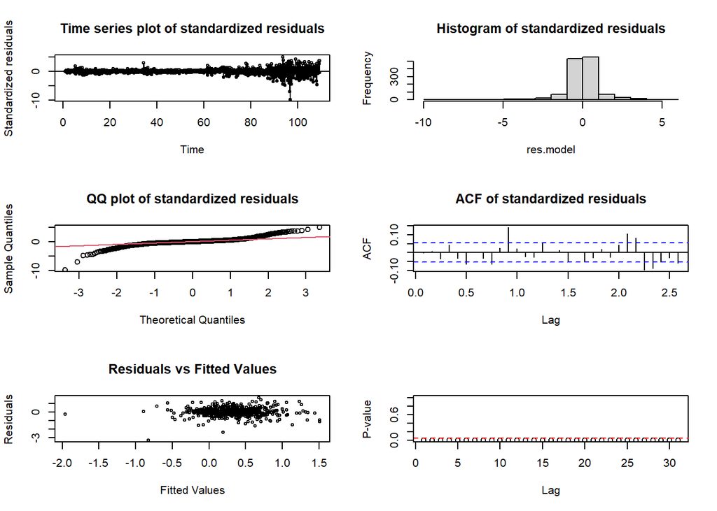

```r
plot(baseline_model$fitted, baseline_model$residuals, main = "Residuals vs Fitted Values", xlab = "Fitted Values", ylab = "Residuals")

McLeod.Li.test(baseline_model)
```

**AICc Model Forecast and Accuracy**

Even though the normality and homoscedastic assumption are violated, the forecast and accuracy of the ARIMA model is decent.

```r
forecast_baseline <- forecast::forecast(baseline_model, h = 6)

# Obtain the original scale forecasts by applying inverse differencing
forecast_values <- diffinv(forecast_baseline$mean, xi = tail(traints, 1))

#Accuracy Test
accuracy1 <- accuracy(forecast_values, test$CPI)
print(accuracy1)
```

```
##                 ME     RMSE      MAE       MPE     MAPE
## Test set -7.151799 7.808743 7.151799 -2.694711 2.694711
```

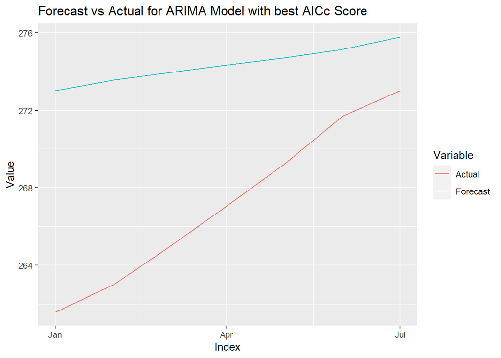

```r
# Create a data frame with forecasted values and actual values
df <- data.frame(
  Index = test$Yearmon,
  Value = c(forecast_values, test$CPI),
  Variable = rep(c("Forecast", "Actual"), each = length(forecast_values))
)

# Load the required library
library(ggplot2)

# Plot the data frame
ggplot(df, aes(x = Index, y = Value, color = Variable)) +
  geom_line() +
  labs(x = "Index", y = "Value", color = "Variable",title = "Forecast vs Actual for ARIMA Model with best AICc Score")
```

**BICc Model Autocorrelation Testing**

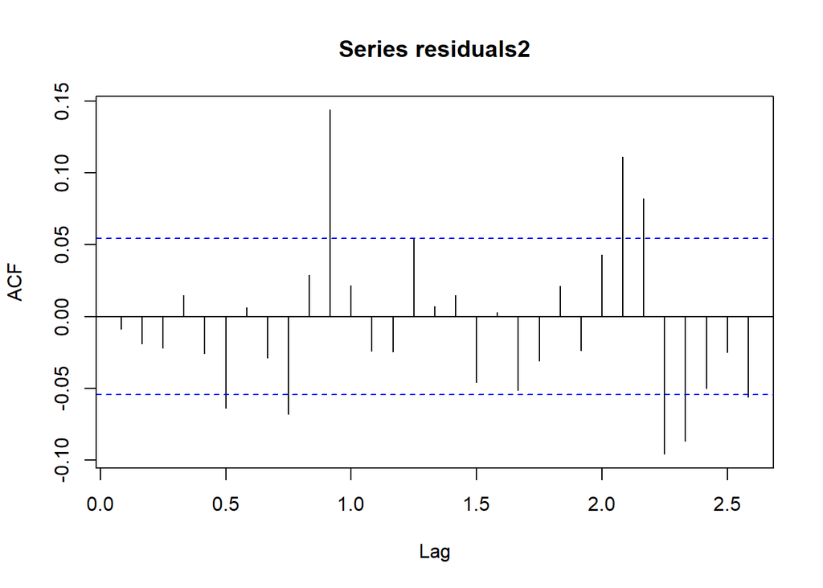

```r
residuals2 <- resid(model_bic)
acf_resid2 <- acf(residuals2)
```

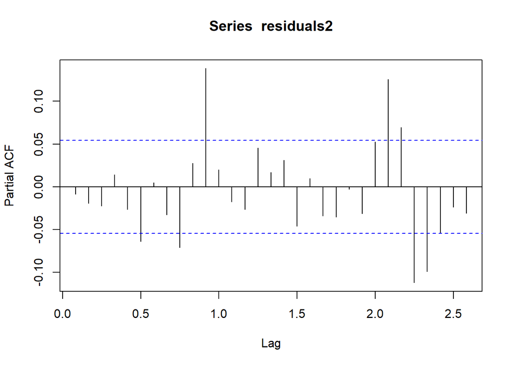

```r
pacf_resid2 <- pacf(residuals2)
```

```r
Box.test(model_bic$residuals, type='Ljung-Box')
```

```
##
##  Box-Ljung test
##
## data:  model_bic$residuals
## X-squared = 0.099031, df = 1, p-value = 0.753
```

```r
# Perform the ADF test
  adf_result2 <- adf.test(model_bic$residuals)
    #cat(paste0(colnames(data), " ADF test p-value: ", adf_result1$p.value, "\n"))
adf_result2
```

```
##
##  Augmented Dickey-Fuller Test
##
## data:  model_bic$residuals
## Dickey-Fuller = -9.7708, Lag order = 10, p-value = 0.01
## alternative hypothesis: stationary
```

```r
# Perform the KPSS test
  kpss_result2 <- kpss.test(model_bic$residuals)
kpss_result2
```

```
##
##  KPSS Test for Level Stationarity
##
## data:  model_bic$residuals
## KPSS Level = 0.13147, Truncation lag parameter = 7, p-value = 0.1
```

**Checking BICc model for Normality and Heteroscedasticity**

The Shapiro-Wilk test is used to determine if a dataset significantly deviates from a normal distribution. In this case, with a p-value of less than 2.2e-16, which is extremely small, we reject the null hypothesis of normality. This indicates that the dataset being tested does not follow a normal distribution.We can also see from the qqplot, that residuals are not normal. This violates one of the assumption of the SARIMA models.

From the residual vs fitted values plot, McLeod.Li.test and the time series plot, we can see that there is Heteroscedasticity, which also violates another assumption of the model.Heteroscedasticity refers to a situation in which the variability or dispersion of errors (residuals) in a regression or time series model is not constant across different levels of the independent variables or across different time periods.

In conclusion, we should utilize and alternative model to ARIMA.

```r
#install.packages(fitar)
residual.analysis <- function(model, std = TRUE){
  library(TSA)
  #library(FitAR)
  if (std == TRUE){
    res.model = rstandard(model)
  }else{
    res.model = residuals(model)
  }
  par(mfrow=c(3,2))
  plot(res.model,type='o',ylab='Standardized residuals', main="Time series plot of standardized residuals")
  abline(h=0)
  hist(res.model,main="Histogram of standardized residuals")
  qqnorm(res.model,main="QQ plot of standardized residuals")
  qqline(res.model, col = 2)
  acf(res.model,main="ACF of standardized residuals")
  print(shapiro.test(res.model))
  k=0
}

residual.analysis(model=model_bic)
```

```
##
##  Shapiro-Wilk normality test
##
## data:  res.model
## W = 0.83526, p-value < 2.2e-16
```

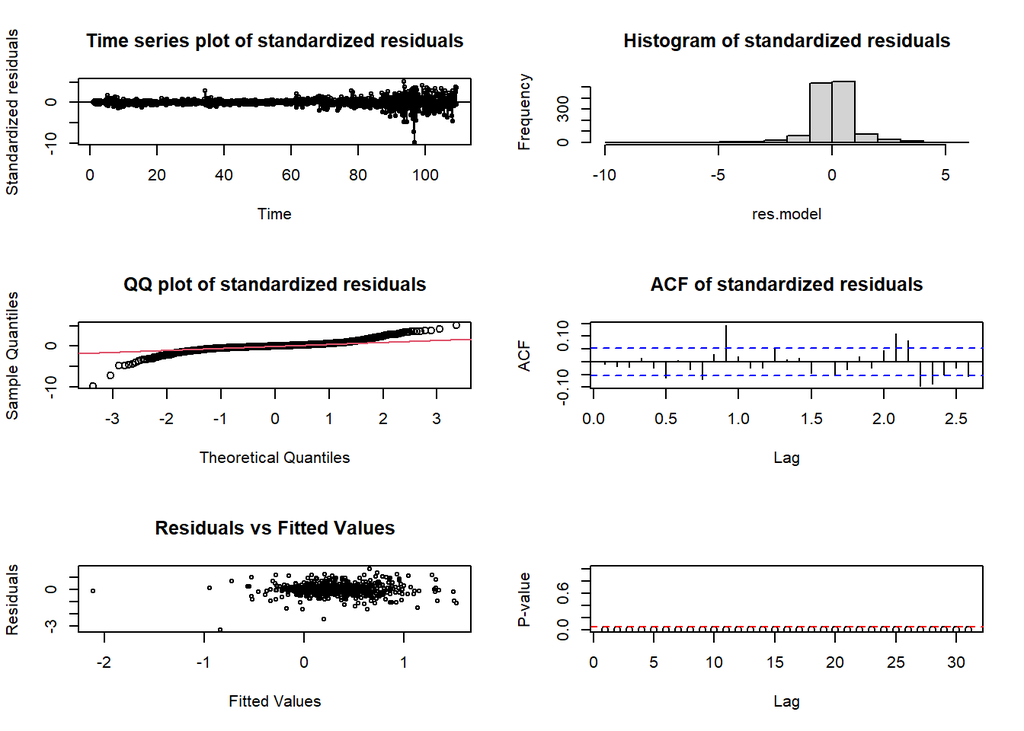

```r
plot(model_bic$fitted, model_bic$residuals, main = "Residuals vs Fitted Values", xlab = "Fitted Values", ylab = "Residuals")

McLeod.Li.test(model_bic)
```

**BICc Model Forecast and Accuracy**

Even though the normality and homoscedastic assumption are violated, the forecast and accuracy of the ARIMA model is decent.

The AICc model had a slightly bettter accuracy score than the BICc model.

```r
forecast_BICc <- forecast::forecast(model_bic, h = 6)

# Obtain the original scale forecasts by applying inverse differencing
forecast_values1 <- diffinv(forecast_BICc$mean, xi = tail(traints, 1))

#Accuracy Test
accuracy2 <- accuracy(forecast_values1, test$CPI)
print(accuracy2)
```

```
##                 ME     RMSE      MAE      MPE    MAPE
## Test set -7.263182 7.892541 7.263182 -2.73614 2.73614
```

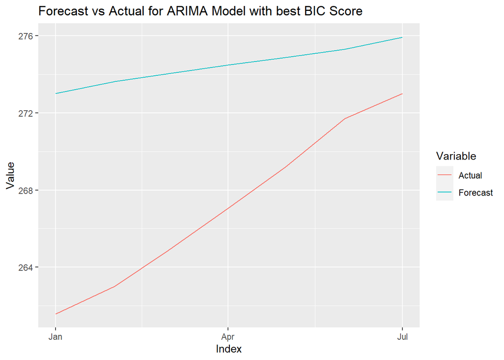

```r
# Create a data frame with forecasted values and actual values
df <- data.frame(
  Index = test$Yearmon,
  Value = c(forecast_values1, test$CPI),
  Variable = rep(c("Forecast", "Actual"), each = length(forecast_values1))
)

# Load the required library
library(ggplot2)

# Plot the data frame
ggplot(df, aes(x = Index, y = Value, color = Variable)) +
  geom_line() +
  labs(x = "Index", y = "Value", color = "Variable",title = "Forecast vs Actual for ARIMA Model with best BIC Score")
```

**ARFIMA Model**

ARFIMA stands for Autoregressive Fractionally Integrated Moving Average, which is a type of time series model that extends the traditional ARIMA model to include long memory or long-range dependence in the data. ARFIMA models are also known as FARIMA models, where the “F” stands for fractional differencing.

In a traditional ARIMA model, the data is assumed to be stationary, meaning that the mean and variance of the data are constant over time. Additionally, the model assumes that the data has a finite memory length, which is captured by the differencing parameter “d”. The ARFIMA model relaxes these assumptions by allowing for the inclusion of fractional differencing.

Fractional differencing is a technique that allows for the estimation of the memory parameter “d” to take on fractional values, rather than being limited to integer values. Fractional differencing is achieved by applying a fractional-order differencing operator to the time series. The degree of memory in the data is represented by the value of “d”, where a value of 0 indicates no memory, and a value of 1 indicates long memory.

The ARFIMA model is denoted as ARFIMA(p, d, q), where “p” is the order of the autoregressive component, “q” is the order of the moving average component, and “d” is the differencing parameter. The model can be estimated using maximum likelihood estimation, and the parameters can be used to generate forecasts for the time series.

ARFIMA models are particularly useful for modeling financial and economic time series data, which often exhibit long memory or long-range dependence. They can also be used to model other types of data, such as climate data, geophysical data, and network traffic data.

```r
library(arfima)
#find lag value/d
#library(fracdiff)
#d <- fracdiff(traints)


arfima_model <- forecast::arfima(differenced_ts)

summary(arfima_model)
```

```
##
## Call:
##   forecast::arfima(y = differenced_ts)
##
## *** Warning during (fdcov) fit: unable to compute correlation matrix; maybe change 'h'
##
## Coefficients:
##        Estimate
## d         0.470
## ar.ar1    0.992
## ar.ar2   -0.338
## ma.ma1    0.845
## sigma[eps] = 0.3426843
## [d.tol = 0.0001221, M = 100, h = 4.799e-06]
## Log likelihood: -454.5 ==> AIC = 918.9409 [5 deg.freedom]
```

**ARFIMA Assumptions**

Residual vs Fitted values plot and the time series plot of the residuals shows that the homoscedasticity is violated.

Similarly, the residuals of the ARIMA model are not normally distributed as show by the qqplot and the shapiro.test.

So we should look for an alternative model.

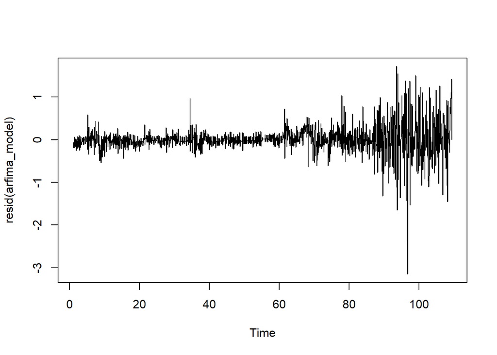

```r
#autocorrelation issue seems to be resolved
plot(resid(arfima_model))
```

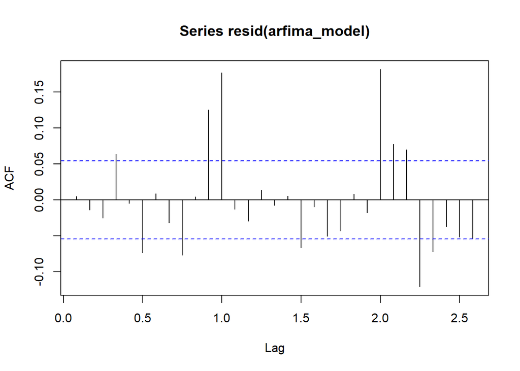

```r
acf(resid(arfima_model))
```

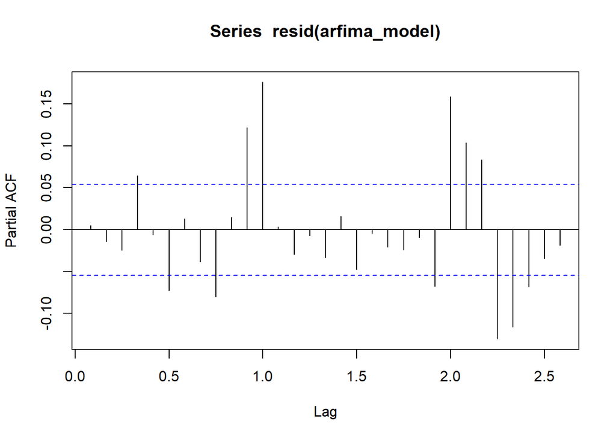

```r
pacf(resid(arfima_model))
```

```r
# Perform the ADF test
  kpss_result2 <- kpss.test(arfima_model$residuals)
  adf_result2 <- adf.test(arfima_model$residuals)
    #cat(paste0(colnames(data), " ADF test p-value: ", adf_result1$p.value, "\n"))
adf_result2
```

```
##
##  Augmented Dickey-Fuller Test
##
## data:  arfima_model$residuals
## Dickey-Fuller = -10.267, Lag order = 10, p-value = 0.01
## alternative hypothesis: stationary
```

```r
# Perform the KPSS test
kpss_result2
```

```
##
##  KPSS Test for Level Stationarity
##
## data:  arfima_model$residuals
## KPSS Level = 0.80991, Truncation lag parameter = 7, p-value = 0.01
```

```r
#Ljung-Box test
Box.test(arfima_model$residuals, type='Ljung-Box')
```

```
##
##  Box-Ljung test
##
## data:  arfima_model$residuals
## X-squared = 0.029674, df = 1, p-value = 0.8632
```

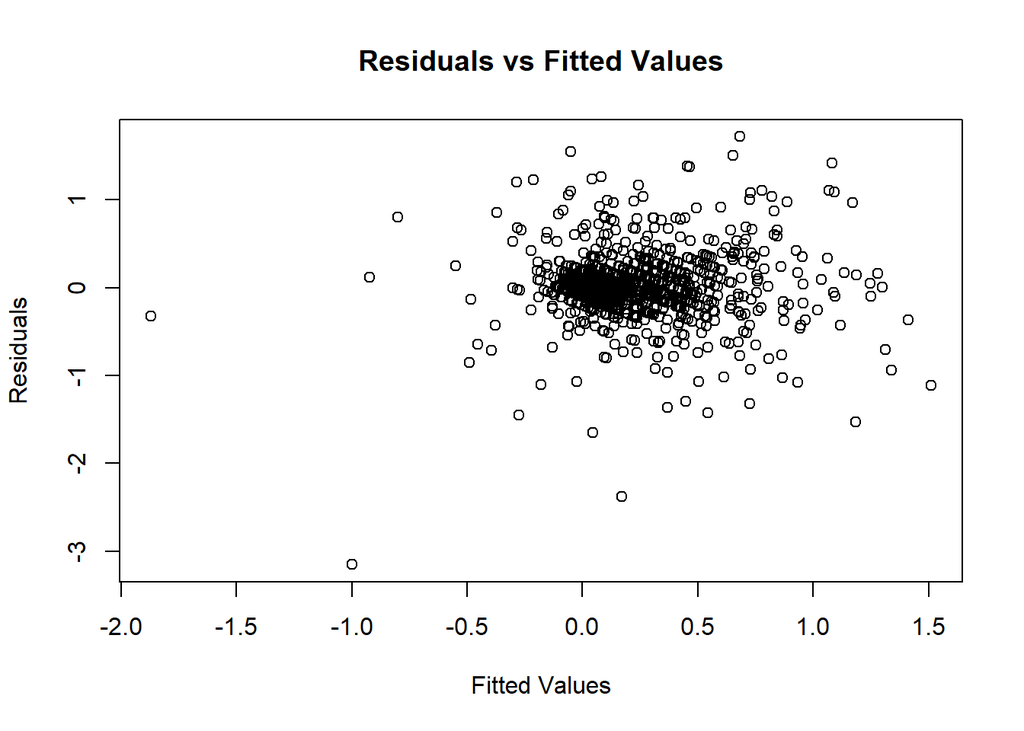

```r
plot(arfima_model$fitted, arfima_model$residuals, main = "Residuals vs Fitted Values", xlab = "Fitted Values", ylab = "Residuals")
```

```r
shapiro.test(arfima_model$residuals)
```

```
##
##  Shapiro-Wilk normality test
##
## data:  arfima_model$residuals
## W = 0.83843, p-value < 2.2e-16
```

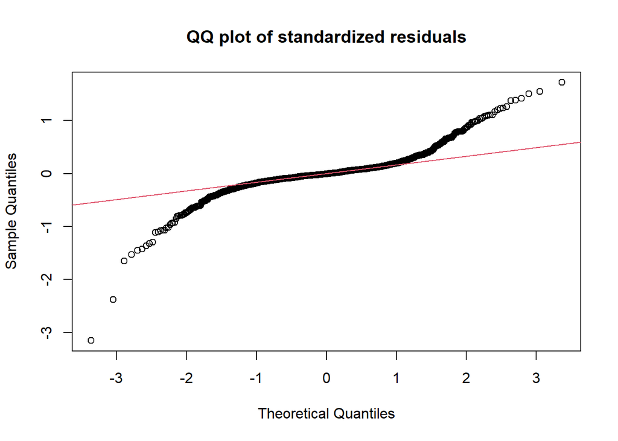

```r
qqnorm(arfima_model$residuals,main="QQ plot of standardized residuals")
qqline(arfima_model$residuals, col = 2)
```

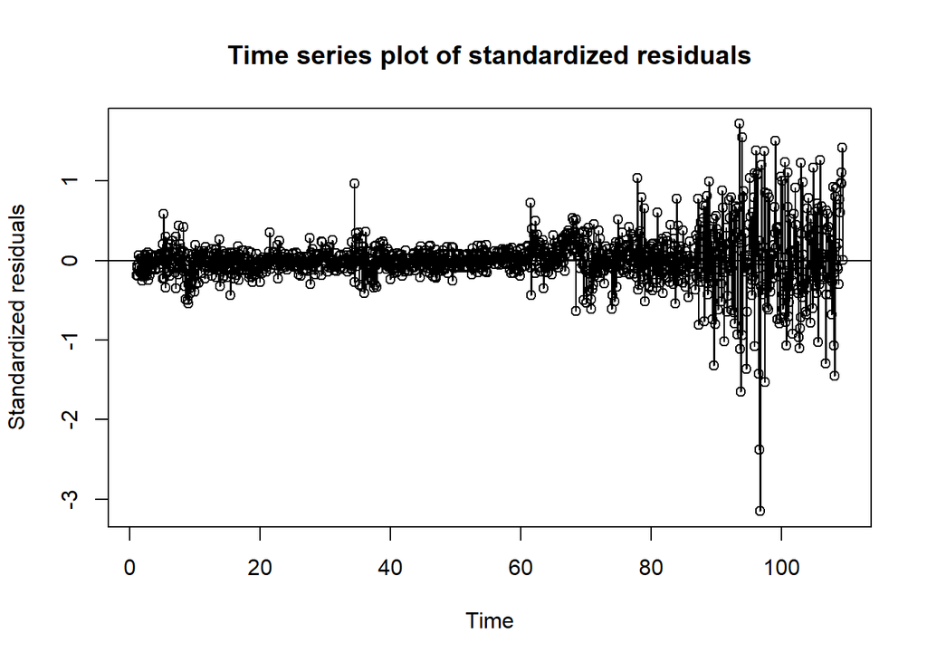

```r
plot(arfima_model$residuals,type='o',ylab='Standardized residuals', main="Time series plot of standardized residuals")
  abline(h=0)
```

**Forecast and Accuracy of ARFIMA Model**

The ARFIMA Model has a better accuracy than the two ARIMA models when comparing the RMSE and MAE. However, similar to the ARIMA model, it violates the normality and homoscedastic assumption,so we will look at another model.

```r
forecast_arfima<- forecast::forecast(arfima_model, h = 6)

# Obtain the original scale forecasts by applying inverse differencing
forecast_arfimavalues <- diffinv(forecast_arfima$mean, xi = tail(traints, 1))

#Accuracy Test
accuracy2 <- accuracy(forecast_arfimavalues, test$CPI)
print(accuracy2)
```

```
##                 ME     RMSE      MAE       MPE     MAPE
## Test set -6.893203 7.638543 6.893203 -2.598787 2.598787
```

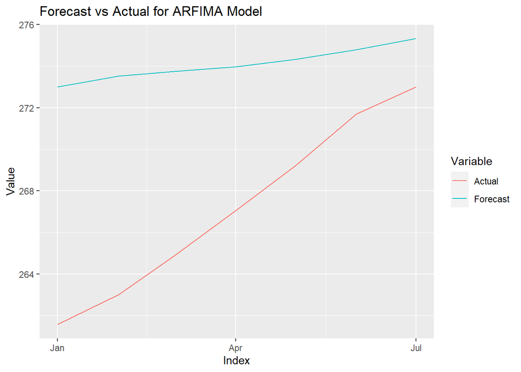

```r
# Create a data frame with forecasted values and actual values
dfarfima <- data.frame(
  Index = test$Yearmon,
  Value = c(forecast_arfimavalues, test$CPI),
  Variable = rep(c("Forecast", "Actual"), each = length(forecast_arfimavalues))
)

# Plot the data frame
ggplot(dfarfima, aes(x = Index, y = Value, color = Variable)) +
  geom_line() +
  labs(x = "Index", y = "Value", color = "Variable",title = "Forecast vs Actual for ARFIMA Model")
```

```r
summary(arfima_model)
```

```
##
## Call:
##   forecast::arfima(y = differenced_ts)
##
## *** Warning during (fdcov) fit: unable to compute correlation matrix; maybe change 'h'
##
## Coefficients:
##        Estimate
## d         0.470
## ar.ar1    0.992
## ar.ar2   -0.338
## ma.ma1    0.845
## sigma[eps] = 0.3426843
## [d.tol = 0.0001221, M = 100, h = 4.799e-06]
## Log likelihood: -454.5 ==> AIC = 918.9409 [5 deg.freedom]
```

**Holt-Winters Model**

Holt-Winter model is also great at forecasting for a time series with trend and seasonal component.

Checking the assumptions of the Holt-winters:

ADF KPSS test suggest the residuals are stationary.

So we should look for an alternative model.

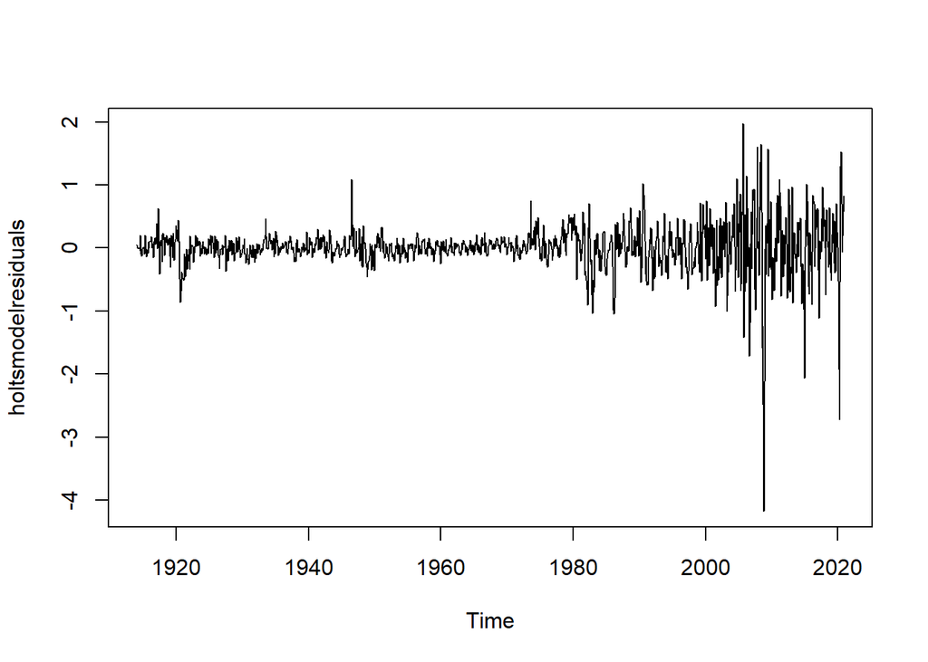

```r
holtsmodel <- HoltWinters(traints1,seasonal = "multiplicative")


holtsmodelresiduals <- residuals(holtsmodel)


plot(holtsmodelresiduals)
```

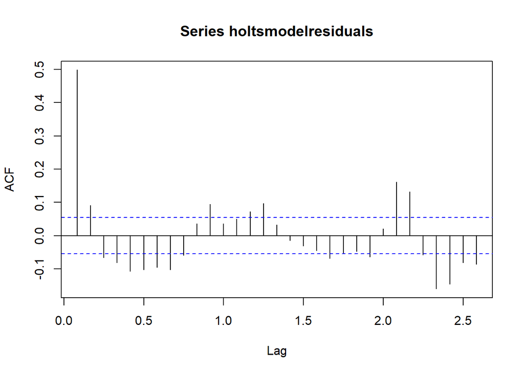

```r
acf(holtsmodelresiduals)
```

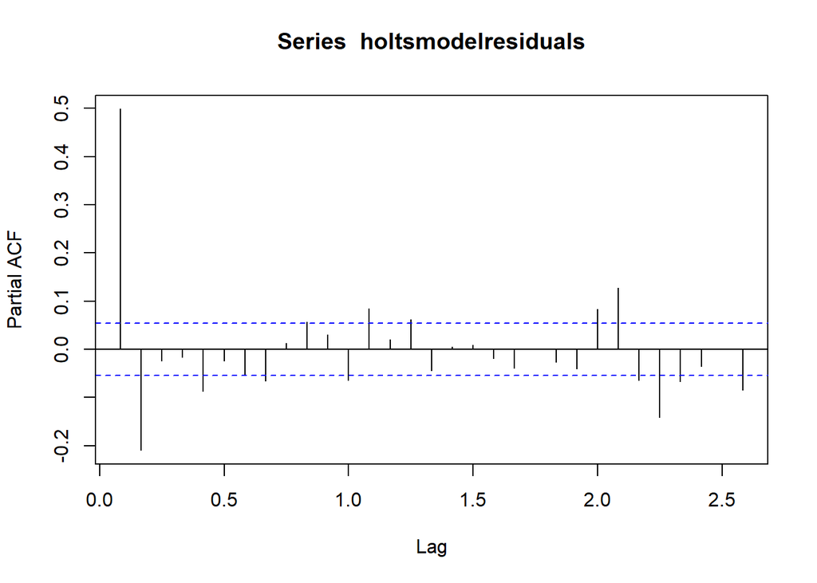

```r
pacf(holtsmodelresiduals)
```

```r
 kpss.test(holtsmodelresiduals)
```

```
##
##  KPSS Test for Level Stationarity
##
## data:  holtsmodelresiduals
## KPSS Level = 0.026347, Truncation lag parameter = 7, p-value = 0.1
```

```r
 adf.test(holtsmodelresiduals)
```

```
##
##  Augmented Dickey-Fuller Test
##
## data:  holtsmodelresiduals
## Dickey-Fuller = -10.797, Lag order = 10, p-value = 0.01
## alternative hypothesis: stationary
```

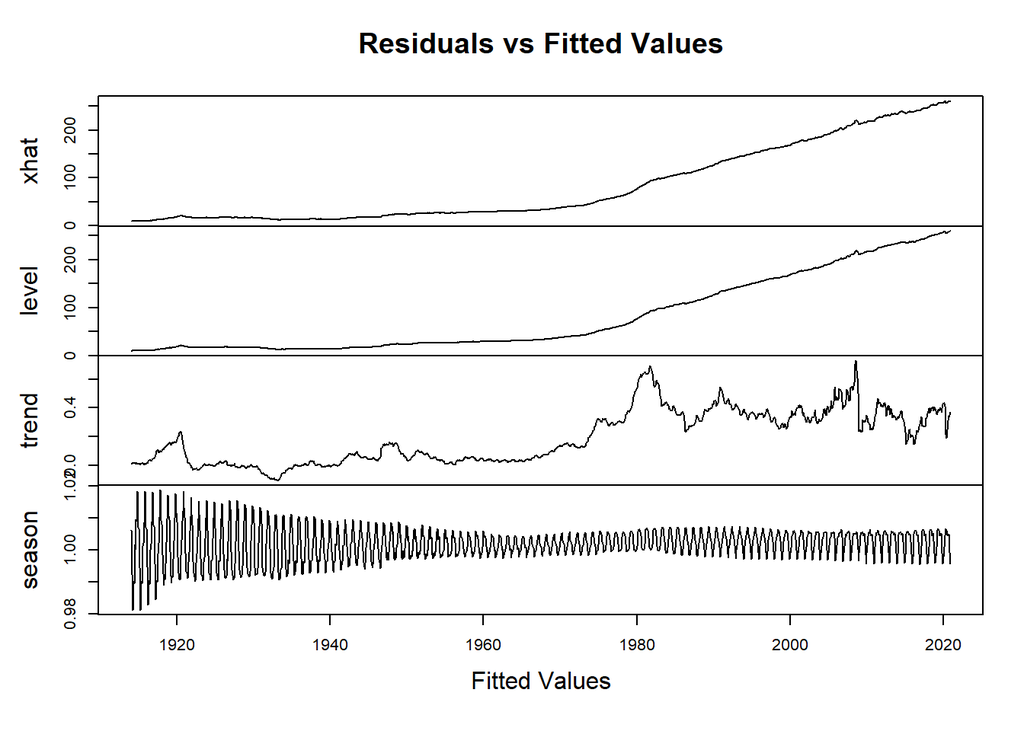

```r
plot(holtsmodel$fitted, holtsmodelresiduals, main = "Residuals vs Fitted Values", xlab = "Fitted Values", ylab = "Residuals")
```

```r
shapiro.test(holtsmodelresiduals)
```

```
##
##  Shapiro-Wilk normality test
##
## data:  holtsmodelresiduals
## W = 0.81086, p-value < 2.2e-16
```

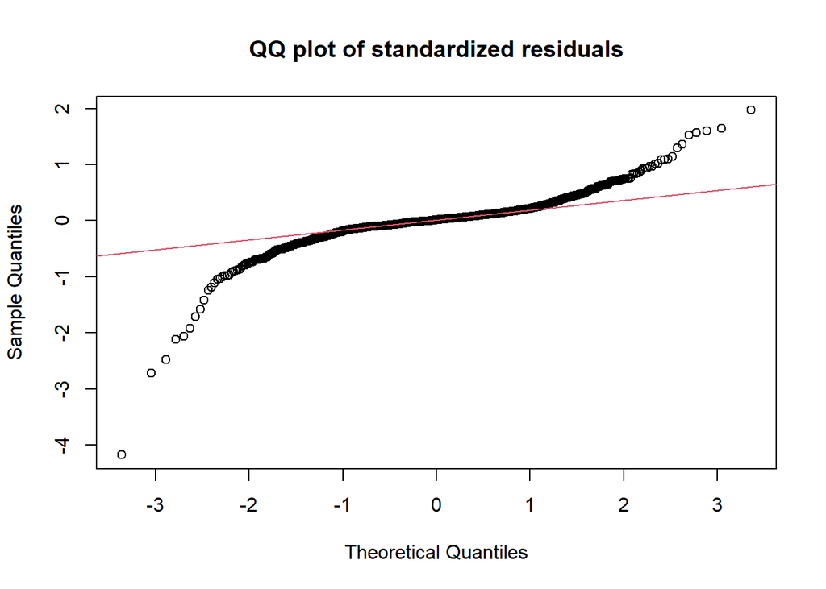

```r
qqnorm(holtsmodelresiduals,main="QQ plot of standardized residuals")
qqline(holtsmodelresiduals, col = 2)
```